# CSG Jupyter Notebook Tutorial

Tutorial and supporting files can be downloaded from:

https://github.com/welchr/csg-jupyter-tutorial

## What is the Jupyter notebook?

A web-based application for creating documents of code, visualizations, and text. It supports multiple languages (primary language is Python, but R works as well, as well as Julia.)

If you're watching me give this tutorial live, then what you're looking at is the Jupyter notebook!

The notebook contains cells, which can be of multiple types:

- Markdown (a simple markup language)
- Code

Code cells can be a number of different languages:

- Python
- Javascript
- Bash
- HTML
- R

## What can you do with it?

Exploratory data analysis

- Keep code, data, and plots together in one place
- Easy to keep track of the formats of different data frames, column types, etc.
- When working with collaborators, you can make quick changes or try different things, without having to go back and re-generate plots for one-off ideas

Creating reports of analysis results to share with collaborators

- Compile notebook into HTML documents to share - single document with interactive (or static) plots and text
- If data changes, simple to re-run entire notebook and generate the report again

Teaching demonstrations

- Create a full lecture, but still allow on-the-fly coding/questions

Reproducible research

- Send data + notebook and collaborators can re-run your analysis
- Add Docker, and they don't need to install any packages either

Visualizing a "proof" that an algorithm or function works correctly

- Keep a notebook next to your code, e.g. invnorm.py and invnorm.ipynb.
- This way, if tables or figures make it easier to show that your code works correctly, they will be near the actual code and easy to find
- Not a substitute for writing test cases

## How do I install it?

Follow the instructions here on getting setup with either miniconda or linuxbrew:

https://github.com/statgen/csg-python

If you're unsure of which to pick or need a quick answer, go with miniconda.

Once you've installed miniconda, you can simply do:

```
conda install jupyter
```

## How do I run it?

### On your own computer

On Windows, there should be an icon on the desktop, or search for jupyter by hitting Win+S.

On OSX or Linux, you can type the following in a terminal:

```
jupyter notebook &
```

A browser window should open, and you'll be able to see the jupyter notebook server running on your computer.

### On a remote server (like snowwhite, dumbo, etc.)

#### Remote kernel approach

This is the simplest approach, but also the least well tested. Your mileage may vary.

Install the `remote_ikernel` package:

```
pip3 install remote_ikernel
```

And then add a remote kernel, for example on snowwhite:

```
remote_ikernel manage --add \
    --kernel_cmd="ipython3 kernel -f {connection_file}" \
    --name="Python3 (snowwhite)" --interface=ssh \
    --host=welchr@snowwhite.sph.umich.edu
```

Now, when you go to create a new notebook, you should see your remote kernel in the list.

#### SSH tunneling approach

1. Setup a jupyter notebook password

   When running the notebook on a remote server, you should set a password. Otherwise, someone could potentially connect to your notebook, and have an open python shell with your user privileges. Not good. First, generate a password, like so:

   ```
   from notebook.auth import passwd
    passwd()
   ```

   You should end up with a password hash that looks something like a random string, for example: `'sha1:2a12986a580e:f5830338dbdf89412fe1b94e5342c369e8e41819'`

   Now copy the hash into your `~/.jupyter/jupyter_notebook_config.py` file:

   ```
   c.NotebookApp.password = u'<copy string from above>'
   ```

   If this file doesn't exist, you can generate it by doing:

   ```
   jupyter notebook --generate-config
   ```

2. Create an SSH key

   You will need to be able to login to the remote server with an SSH key. This allows you to create SSH tunnels without needing to enter your password each time.

   A great tutorial for this is here: https://www.digitalocean.com/community/tutorials/how-to-set-up-ssh-keys--2 (steps 1-3)
3. Setup AutoSSH

   This tool helps keep an SSH tunnel open between your machine and the server.

   ```
   # For Linux (if you're on your own linux machine, not our servers)
    sudo apt-get install autossh

    # For OSX
    brew install autossh

    # For Windows
    # Use cygwin - the package manager has autossh.

    # If none of those are options, follow the instructions to build the source
    # code directly at: http://www.harding.motd.ca/autossh/
   ```

   Create the SSH tunnel:

   ```
   # Choose a random number 1024 < x < 65535. For example, 21325.
    # 21325 will be the monitoring port autossh uses to make sure the connection is still alive.
    # 5656 is the default jupyter notebook server port
    autossh -M 21325 -f -i ~/.ssh/id_rsa -N -L 5656:localhost:5656 user@machine.sph.umich.edu
   ```

4. Run the jupyter notebook on the server

   Connect to the server (snowwhite, dumbo, etc.) and run:

   ```
   jupyter notebook --no-browser &
   ```

5. Open your local browser

   Open Chrome or Safari on your computer and enter the address `http://localhost:5656/`.

   You may get a warning about SSL certificates / safety - this is one of those rare instances where it is OK to ignore - hit "Advanced" at the bottom and then "Proceed anyway." Your connection is encrypted via SSH.

## Basics

### Keyboard shortcuts

These are really important to being able to use the notebook quickly. To see a pop-up of all keyboard shortcuts, click outside of a cell or press ESC (to get out of edit mode) and then press "h".

### Getting help

Another important feature is to type something into a cell for which you need help with, and then end it with a ?. For example:

`np.linalg.svd?`

Should pop up a little window explaining more about it. You can hit **q** to quickly get rid of the window.

## Markdown Cells

In the notebook, you can have cells written in a markup language called [Markdown](http://daringfireball.net/projects/markdown/syntax). It's a relatively simple language and is used for most README files on [Github](https://github.com/).

To make a markdown cell, select the cell and press "M". You should see the little "In [#]" disappear next to the cell. Alternatively, you can use the "Cell" menu and go to Cell Type $\dashrightarrow$ Markdown.

Markdown cells are mainly used to either document what you're doing in the notebook, or they can be used to show code inline. For example:

Here is my algorithm:

1. Step 1
2. Step 2
3. Step 3

And the code for this algorithm:

```
def step1():
  pass

def step2():
  pass

def step3():
  pass
```

You can do a number of interesting things in markdown cells. For one, you can render math or LaTeX expressions, for example:

**Input:**

`Deviance residual = $l_j$=$\pm\sqrt{2[d_j\log\frac{d_j}{m_j\hat{\pi}_j} + (m_j-d_j)\log{\left(\frac{(m_j-d_j)}{m_j(1-\hat{\pi}_j)}\right)}]}$`

**Output:**

Deviance residual = $l_j$=$\pm\sqrt{2[d_j\log\frac{d_j}{m_j\hat{\pi}_j} + (m_j-d_j)\log{\left(\frac{(m_j-d_j)}{m_j(1-\hat{\pi}_j)}\right)}]}$

Sympy also works well with the Jupyter notebook, and will display its results inline and formatted. For example:

$$\left [ - i \sqrt{- \frac{1}{2} + \frac{\sqrt{5}}{2}}, \quad i \sqrt{- \frac{1}{2} + \frac{\sqrt{5}}{2}}, \quad - \sqrt{\frac{1}{2} + \frac{\sqrt{5}}{2}}, \quad \sqrt{\frac{1}{2} + \frac{\sqrt{5}}{2}}\right ]$$

Surprisingly this works for some large ugly matrices:

$$\left[\begin{matrix}\frac{1}{m_{11}} + \frac{m_{12} m_{21}}{m_{11}^{2} \left(m_{22} - \frac{m_{12} m_{21}}{m_{11}}\right)} & - \frac{m_{12}}{m_{11} \left(m_{22} - \frac{m_{12} m_{21}}{m_{11}}\right)}\\- \frac{m_{21}}{m_{11} \left(m_{22} - \frac{m_{12} m_{21}}{m_{11}}\right)} & \frac{1}{m_{22} - \frac{m_{12} m_{21}}{m_{11}}}\end{matrix}\right]$$

## Code cells

If you created the notebook with a python kernel (the default), you can enter python code into any newly created cell:

```
0
1
2
3
4
```

However, you can still run other languages within cells, such as bash, javascript, HTML, etc. For example:

```
total 4748
-rw-r----- 1 welchr welchr    4359 Jun  2 10:57 basic_noin.tpl
-rwxr-x--- 1 welchr welchr     189 Jun  2 10:37 build_html.sh
-rw-r----- 1 welchr welchr 1312410 Jun  2 12:31 csg_jupyter_tutorial.html
-rw-r----- 1 welchr welchr 1153145 Jun  2 12:30 csg_jupyter_tutorial.ipynb
-rw-r----- 1 welchr welchr 1268370 Jun  2 12:31 csg_jupyter_tutorial_nocode.html
-rw-r----- 1 welchr welchr    1900 Jun  2 10:57 full_noin.tpl
-rw-r----- 1 welchr welchr   22781 Jun  1 22:05 images_etv5.png
-rw-r----- 1 welchr welchr   60947 Jun  1 22:05 jupyter_diagram_local.png
-rw-r----- 1 welchr welchr   65983 Jun  1 22:05 jupyter_diagram_remote.png
-rw-r----- 1 welchr welchr    1626 Jun  2 12:28 README.md
-rw-r----- 1 welchr welchr     593 Jun  1 22:05 styles.css
```

Arbitrary HTML

## Plotting

### Python

#### Seaborn

[Seaborn](https://stanford.edu/~mwaskom/software/seaborn/api.html) is a plotting library for Python that uses matplotlib underneath the hood. It provides for a number of plotting types that don't exist in matplotlib.

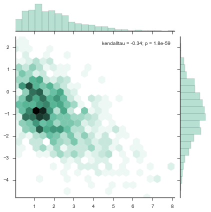

#### Interactive plotting with bokeh

You can view some [example plots](http://bokeh.pydata.org/en/latest/docs/gallery.html) on the [Bokeh website](http://bokeh.pydata.org/en/latest/).

Loading BokehJS ...

### R plotting

#### Plotting with ggplot or lattice

Start with a data frame of fake data:

|  | x | y |
| --- | --- | --- |
| 0 | 0.704454 | 2.037006 |
| 1 | -1.194982 | 1.360593 |
| 2 | -1.096432 | 0.760738 |
| 3 | -0.208898 | 0.247912 |
| 4 | 1.529051 | 0.317931 |
| 5 | -0.532387 | -0.665533 |
| 6 | 0.077326 | 1.647296 |
| 7 | 0.103500 | 0.005431 |
| 8 | -1.511415 | -0.424671 |
| 9 | -0.383003 | -0.276754 |

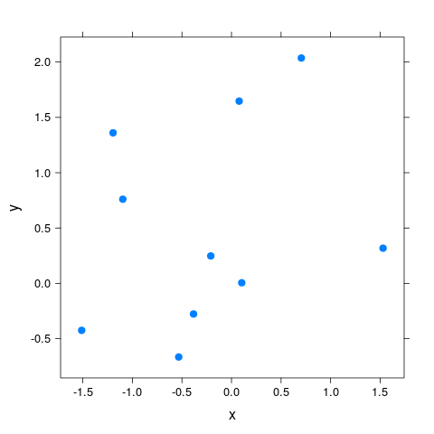

#### Plotting with rbokeh

R has a port of bokeh called [rbokeh](http://hafen.github.io/rbokeh/).

If you're using R as usual, you can install it with:

```
install.packages("rbokeh")
```

Or if you're using conda:

```
conda install -c r r-rbokeh
```

To make plots appear in the notebook, Lars provides this nice method:

[output not shown]

## Including media

You can include images that have already been created elsewhere:

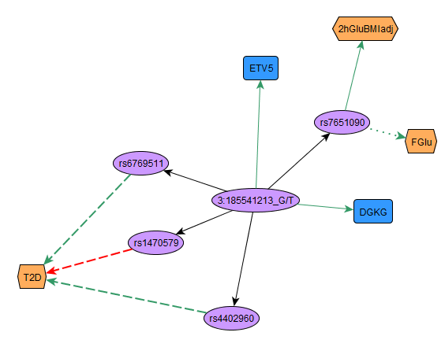

## Creating reports from a notebook

### With code cells included

If you don't mind code cells included in your HTML report, just go to the **File** menu, and go to **Download as --> HTML**. You could also save as PDF and other formats.

### With code cells excluded

This is slightly more involved. Apparently jupyter cannot enable this functionality by default due to patent issues.

First, you'll want to grab some custom templates that we've created that remove code cells when you generate the HTML output from your notebook. Jupyter doesn't do this by default (potentially because of a patent/licensing issue.)

The templates are located here:

```
/net/snowwhite/home/welchr/scratch/jupyter_templates/basic_noin.tpl
/net/snowwhite/home/welchr/scratch/jupyter_templates/full_noin.tpl
```

They are also located in the github repository as well.

You'll want to copy those somewhere, a good location would be: `~/.jupyter/templates/`.

Now, edit your `~/.jupyter/jupyter_nbconvert_config.py` file to have this:

```
c.HTMLExporter.template_path = ['.','/home/<you>/.jupyter/templates/']
```

*If you don't have a jupyter_nbconvert_config.py file* , then you can create one by doing:

```
jupyter nbconvert --generate-config
```

Finally, you can create a nice HTML report from your notebooks by doing:

```
jupyter nbconvert --to html --template full_noin <notebook file>
```

You can also write PDF and other formats as well.

## Executing notebooks offline (not in a browser)

You can execute an entire notebook without having to use your browser. This can be useful for long running notebooks, or when you might lose your browser connection.

First, make one small tweak to your notebook config (`~/.jupyter/jupyter_nbconvert_config.py`) that allows for longer execution times:

```
c.ExecutePreprocessor.timeout = 9999999
```

Use the following command:

```
jupyter nbconvert --execute --allow-errors --inplace --to notebook --template full_noin <notebook file>
```

This will execute your notebook, skipping cells that have errors (`--allow-errors`). Results and output will be saved back into your notebook (.ipynb) file.

Now that you've run your notebook, and the results are saved, you could convert the output into a report:

```
jupyter nbconvert --to html --template full_noin <notebook file>
```

**In general** it is advisable to isolate long running code as separate scripts/jobs, and then import the results of those jobs into your notebook for display and visualization.

## Helpful hints

**The session seems to be locked up. What do I do now?**

In the top menus, try Kernel $\dashrightarrow$ Interrupt. If that fails, do Kernel $\dashrightarrow$ Restart.

Failing that, you can always kill the Jupyter notebook process itself, and restart it.

**How do I hide input code cells while in the notebook interface?**

Drop this code into your `~/.jupyter/custom/custom.js` file:

```
code_show = true;
function code_toggle() {
  if (code_show) {
    $("div.input").hide();
    $("div.output_wrapper > div.output:empty").parents("div.cell").hide();
  } else {
    $('div.input').show();
    $("div.output_wrapper > div.output:empty").parents("div.cell").show();
  }

  code_show = !code_show;
}

define(['base/js/namespace','base/js/events'], function(IPython, events) {
  events.on('app_initialized.NotebookApp', function(){
    $("#view_menu").append("<li id=\"toggle_toolbar\" title=\"Show/Hide code cells\"><a href=\"javascript:code_toggle()\">Toggle Code Cells</a></li>");
  });
});
```

This creates an item under the "View" menu to toggle code cells from being shown.

**How do I change the indentation on code?**

Add the following line to your custom.js file (see above):

```
define(['base/js/namespace','base/js/events'], function(IPython, events) {
  events.on('app_initialized.NotebookApp', function(){
    // This sets the indentation within code cells
    IPython.Cell.options_default.cm_config.indentUnit = 2
  });
});
```

**Can I make the notebook wider in my browser?**

Add the following to your custom CSS file `~/.jupyter/custom/custom.css`:

```
.container {
  width: 1400px;
}
```

Or to make it a percent of total width:

```
.container {
  width: 95%;
}
```

## Other resources

[Official Jupyter notebook tutorials](https://github.com/jupyter/notebook/blob/master/docs/source/examples/Notebook/Examples%20and%20Tutorials%20Index.ipynb)

[Jupyter notebook Tutorial / Documentation](https://jupyter-notebook-beginner-guide.readthedocs.org/en/latest/index.html)

[Links to neat/helpful notebooks](http://nb.bianp.net/sort/views/)